# Course Project 1 - Activity Data study

Reproducible Research | JHU | Coursera

Akos Arendas

2024-06-18

# 1 Introduction

This assignment is a study for a course project for a Reproducible Research online course in Coursera, held by Johns Hopkins University.

The following introduction is copied from the project description that gives a background and motivation for the the analysis.

## 1.1 Project description

It is now possible to collect a large amount of data about personal movement using activity monitoring devices such as a Fitbit, Nike Fuelband, or Jawbone Up. These type of devices are part of the “quantified self” movement – a group of enthusiasts who take measurements about themselves regularly to improve their health, to find patterns in their behavior, or because they are tech geeks. But these data remain under-utilized both because the raw data are hard to obtain and there is a lack of statistical methods and software for processing and interpreting the data.

This assignment makes use of data from a personal activity monitoring device. This device collects data at 5 minute intervals through out the day. The data consists of two months of data from an anonymous individual collected during the months of October and November, 2012 and include the number of steps taken in 5 minute intervals each day.

## 1.2 Data

The data for this assignment can be downloaded from the course web site: [Activity monitoring data](https://d396qusza40orc.cloudfront.net/repdata%2Fdata%2Factivity.zip)

The variables included in this dataset are:

- steps: Number of steps taking in a 5-minute interval (missing values are coded as NA)
- date: The date on which the measurement was taken in YYYY-MM-DD format
- interval: Identifier for the 5-minute interval in which measurement was taken

The dataset is stored in a comma-separated-value (CSV) file and there are a total of 17,568 observations in this dataset.

## 1.3 Objectives

Commit containing full submission

1. Code for reading in the dataset and/or processing the data
2. Histogram of the total number of steps taken each day
3. Mean and median number of steps taken each day
4. Time series plot of the average number of steps taken
5. The 5-minute interval that, on average, contains the maximum number of steps
6. Code to describe and show a strategy for imputing missing data
7. Histogram of the total number of steps taken each day after missing values are imputed
8. Panel plot comparing the average number of steps taken per 5-minute interval across weekdays and weekends
9. All of the R code needed to reproduce the results (numbers, plots, etc.) in the report

# 2 Global Options

```r
knitr::opts_chunk$set(echo = TRUE, message = FALSE, warning = FALSE, fig.width = 10, fig.height = 5,
                      fig.keep = 'all' ,fig.path = 'figures\ ', dev = 'png')
```

This code chunk in R markdown sets up some global options for the document. Specifically, it configures the chunk options for the R code chunks in the document.

- `echo = TRUE`: This option determines whether the R code in the chunks will be displayed along with its output.
- `message = FALSE`: This option suppresses messages generated during the code execution.
- `warning = FALSE`: This option suppresses warnings generated during the code execution.
- `fig.width = 10` and `fig.height = 5`: These options specify the width and height of the output figures generated from the code chunks.
- `fig.keep = 'all'`: This option tells the document to keep all figures generated.
- `fig.path = 'figures\ '`: This sets the directory where the figures will be saved.
- `dev = 'png'`: This specifies the device to be used for plotting, in this case, PNG format.

# 3 Loading and pre-processing the data

```r
# Loading packages
library(dplyr)
library(ggplot2)
library(ggthemes)

# Unzipping the file and reading it
path = getwd()
unzip("activity.zip", exdir = path)

activity <- read.csv("activity.csv")

# Setting date format
activity$date <- as.Date(activity$date, "%Y-%m-%d")

# Adding the days to the data set
activity <- activity %>% mutate(day = weekdays(activity$date))

# Viewing the processed data
summary(activity)
```

```
##      steps             date               interval          day
##  Min.   :  0.00   Min.   :2012-10-01   Min.   :   0.0   Length:17568
##  1st Qu.:  0.00   1st Qu.:2012-10-16   1st Qu.: 588.8   Class :character
##  Median :  0.00   Median :2012-10-31   Median :1177.5   Mode  :character
##  Mean   : 37.38   Mean   :2012-10-31   Mean   :1177.5
##  3rd Qu.: 12.00   3rd Qu.:2012-11-15   3rd Qu.:1766.2
##  Max.   :806.00   Max.   :2012-11-30   Max.   :2355.0
##  NA's   :2304
```

# 4 Mean total number of steps taken per day

First let’s calculate the total number of steps taken per day.

```r
steps_per_day <- activity %>%
  group_by(date) %>%
  summarise(total_step = sum(steps, na.rm = TRUE))
```

Table `steps_per_day` contains the dates and the corresponding total steps. Let’s have a look at on the structure of this table:

```r
steps_per_day %>% print(n = 10)
```

```
## # A tibble: 61 × 2
##    date       total_step
##    <date>          <int>
##  1 2012-10-01          0
##  2 2012-10-02        126
##  3 2012-10-03      11352
##  4 2012-10-04      12116
##  5 2012-10-05      13294
##  6 2012-10-06      15420
##  7 2012-10-07      11015
##  8 2012-10-08          0
##  9 2012-10-09      12811
## 10 2012-10-10       9900
## # ℹ 51 more rows
```

Create a histogram with `ggplot2`:

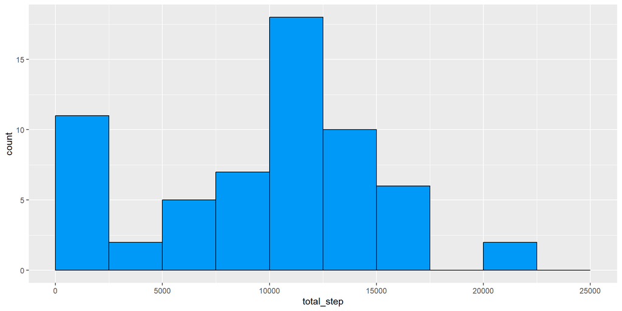

```r
g <- ggplot(steps_per_day, aes(x = total_step)) +
  geom_histogram(breaks = seq(0, 25000, by = 2500), color = "#000000", fill = "#0099F8")
print(g)
```

Calculating the mean and median and adding them to the histogram:

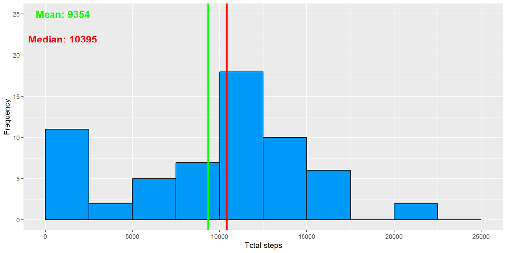

```r
# Mean and median
mean_steps <- mean(steps_per_day$total_step) %>% round(digits = 0)
median_steps <- median(steps_per_day$total_step) %>% round(digits = 0)

# Annotate them
annotation1 <- data.frame(
  x = c(mean_steps, median_steps),
  y = c(25, 22),
  label = c("Mean:", "Median:")
)

g2 <- ggplot(steps_per_day, aes(x = total_step)) +
  geom_histogram(breaks = seq(0, 25000, by = 2500), color = "#000000", fill = "#0099F8") +
  xlab("Total steps") +
  ylab("Frequency") +
  geom_vline(aes(xintercept = mean(total_step)), color = "#00FF00", size = 1.25) +
  geom_vline(aes(xintercept = median(total_step)), color = "#FF0000", size = 1.25) +
  geom_text(data = annotation1,
            aes(x = 1000, y = y, label = paste(label, x)),
            size = 5,
            fontface = "bold",
            color = c("#00FF00", "#FF0000"))
print(g2)
```

As we can see in the plot, the mean is

```r
mean_steps
```

```
## [1] 9354
```

and the median is

```r
median_steps
```

```
## [1] 10395
```

# 5 Average daily activity pattern

The steps are counted for each 5-minute interval. (In one day there is `24 * 60 / 5 = 288` five-minute interval, which equals with the unique values in the interval column of the data)

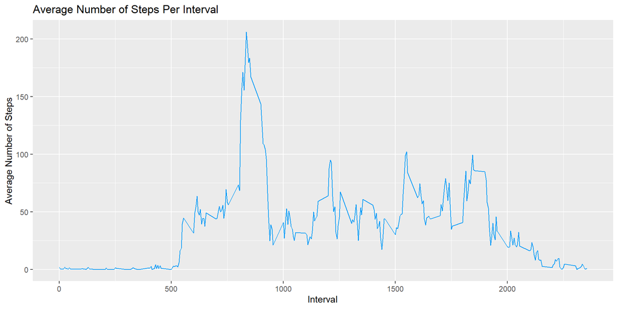

```r
# Calculating the average number of steps taken, averaged across all days by 5-min intervals.
averageDailyActivity <- aggregate(activity$steps,
                                  by = list(activity$interval),
                                  FUN = mean,
                                  na.rm = TRUE)
# Changing col names
names(averageDailyActivity) <- c("Interval", "Mean")

# Converting the data set into a dataframe
averageActivitydf <- data.frame(averageDailyActivity)

# Plotting the result
da1 <- ggplot(averageActivitydf, mapping = aes(Interval, Mean)) +
  geom_line(col = "#0099F8") +
  xlab("Interval") +
  ylab("Average Number of Steps") +
  ggtitle("Average Number of Steps Per Interval")

print(da1)
```

The following interval contains the most steps:

```r
avg_max_int <- averageDailyActivity[which.max(averageDailyActivity$Mean), ]$Interval
avg_max_int
```

```
## [1] 835
```

# 6 Imputing missing values

There are some missing values in the data, which might lead to bias. Hence it’s worth to analyse them further.

First let’s check the the total number of missing values in the dataset (i.e. the total number of rows with NAs).

```r
# Check how many NAs do we have in the different columns
na_count <- colSums(is.na(activity))
na_count
```

```
##    steps     date interval      day
##     2304        0        0        0
```

Only in column `steps` there are occurrences for NA records, thus we can focus on that. For the record, the number of NA values in that column is 2304.

Let’s replace the NAs with estimations. I chose the mest estimates as the median of the corresponding 5-minute interval.

```r
# Replace NAs with the 5-minute interval accordingly
medianIntervalActivity <- aggregate(activity$steps,
                                  by = list(activity$interval),
                                  FUN = median,
                                  na.rm = TRUE)
# Changing colNames
names(medianIntervalActivity) <- c("Interval", "Median")

medianIntervalActivityDf <- data.frame(medianIntervalActivity)

# Replacing NA values in the original dataset with the medians
activity_filled <- activity %>%
  left_join(x = activity,
            y = medianIntervalActivityDf,
            by = c("interval" = "Interval")) %>%
  mutate(steps_final = if_else(is.na(steps), Median, steps))

# New dataset
activity_new <- activity_filled %>%
  select(steps_final, date, interval, day) %>%
  rename(steps = steps_final)

# Check NAs again
na_count_new <- colSums(is.na(activity_new))
na_count_new
```

```
##    steps     date interval      day
##        0        0        0        0
```

Histogram for the filled activity dataset:

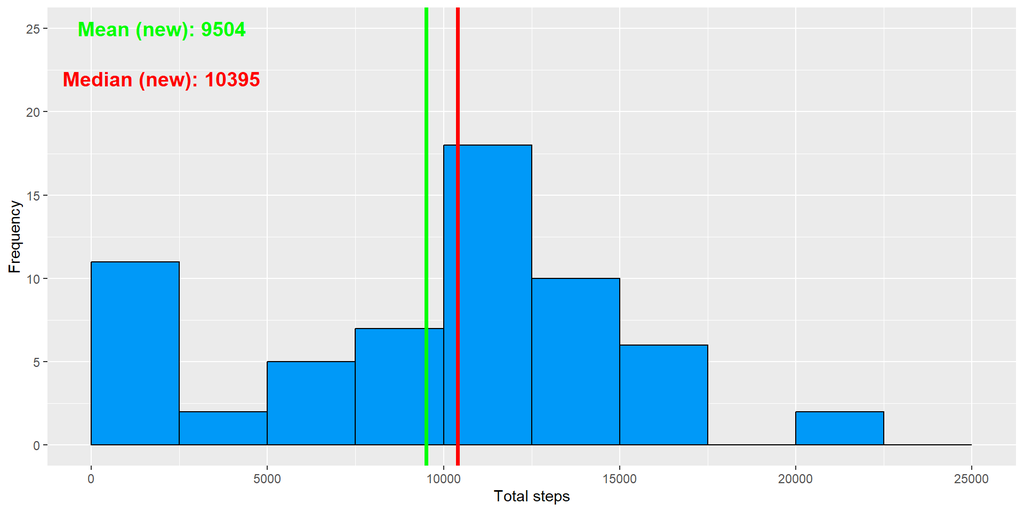

```r
# Steps per day new
steps_per_day_new <- activity_new %>%
  group_by(date) %>%
  summarise(total_step = sum(steps, na.rm = TRUE))

# Mean and median
mean_steps_new <- mean(steps_per_day_new$total_step) %>% round(digits = 0)
median_steps_new <- median(steps_per_day_new$total_step) %>% round(digits = 0)

# Annotate them
annotation2 <- data.frame(
  x = c(mean_steps_new, median_steps_new),
  y = c(25, 22),
  label = c("Mean (new):", "Median (new):")
)

g2 <- ggplot(steps_per_day_new, aes(x = total_step)) +
  geom_histogram(breaks = seq(0, 25000, by = 2500), color = "#000000", fill = "#0099F8") +
  xlab("Total steps") +
  ylab("Frequency") +
  geom_vline(aes(xintercept = mean(total_step)), color = "#00FF00", size = 1.25) +
  geom_vline(aes(xintercept = median(total_step)), color = "#FF0000", size = 1.25) +
  geom_text(data = annotation2,
            aes(x = 2000, y = y, label = paste(label, x)),
            size = 5,
            fontface = "bold",
            color = c("#00FF00", "#FF0000"))
print(g2)
```

As we can see, the impact of replacing the NAs on the mean and on the median is:

```r
chg_mean <- mean_steps_new - mean_steps
chg_mean_perc <- chg_mean / mean_steps
chg_mean
```

```
## [1] 150
```

```r
chg_mean_perc
```

```
## [1] 0.01603592
```

```r
chg_med <- median_steps_new - median_steps
chg_med_perc <- chg_med / median_steps
chg_med
```

```
## [1] 0
```

```r
chg_med_perc
```

```
## [1] 0
```